# 1. Cargar y Preparar los Datos.

```python
import pandas as pd
import numpy as np
from sklearn.model_selection import train_test_split
from sklearn.preprocessing import StandardScaler, OneHotEncoder
from sklearn.compose import ColumnTransformer
from sklearn.pipeline import Pipeline
from sklearn.impute import SimpleImputer
from sklearn.tree import DecisionTreeRegressor
from sklearn.metrics import mean_squared_error, r2_score
from sklearn.linear_model import LinearRegression
from sklearn.neural_network import MLPRegressor
import matplotlib.pyplot as plt

# Cargar el dataset
df = pd.read_csv(r"D:\Zona de trabajo python\Reto IAML\dataset_ML\restaurants_dataset.csv")

# Selección de características y variable objetivo
X = df.drop(columns=['Annual Turnover', 'Registration Number'])
y = df['Annual Turnover']

# División de datos en conjuntos de entrenamiento y prueba
X_train, X_test, y_train, y_test = train_test_split(X, y, test_size=0.2, random_state=42)

# Identificación de variables numéricas y categóricas
num_features = X.select_dtypes(include=['int64', 'float64']).columns
cat_features = X.select_dtypes(include=['object']).columns

# Preprocesamiento para variables numéricas
num_transformer = Pipeline(steps=[
    ('imputer', SimpleImputer(strategy='mean')),
    ('scaler', StandardScaler())
])

# Preprocesamiento para variables categóricas
cat_transformer = Pipeline(steps=[
    ('imputer', SimpleImputer(strategy='most_frequent')),
    ('onehot', OneHotEncoder(handle_unknown='ignore'))
])

# Transformador de columnas
preprocessor = ColumnTransformer(
    transformers=[
        ('num', num_transformer, num_features),
        ('cat', cat_transformer, cat_features)
    ])

# Aplicar preprocesamiento a los datos
X_train = preprocessor.fit_transform(X_train)
X_test = preprocessor.transform(X_test)
```

# 2. Entrenamiento y Evaluación de Modelos

## Regresión Lineal

```python
# Entrenar modelo de regresión lineal
lr_model = LinearRegression()
lr_model.fit(X_train, y_train)

# Predicciones y evaluación
y_pred_lr = lr_model.predict(X_test)
mse_lr = mean_squared_error(y_test, y_pred_lr)
r2_lr = r2_score(y_test, y_pred_lr)
```

## Árboles de Decisión

```python
# Entrenar modelo de árbol de decisión
dt_model = DecisionTreeRegressor(random_state=42)
dt_model.fit(X_train, y_train)

# Predicciones y evaluación
y_pred_dt = dt_model.predict(X_test)
mse_dt = mean_squared_error(y_test, y_pred_dt)
r2_dt = r2_score(y_test, y_pred_dt)
```

## Redes Neuronales

```python
# Entrenar modelo de redes neuronales
nn_model = MLPRegressor(random_state=42, max_iter=500)
nn_model.fit(X_train, y_train)

# Predicciones y evaluación
y_pred_nn = nn_model.predict(X_test)
mse_nn = mean_squared_error(y_test, y_pred_nn)
r2_nn = r2_score(y_test, y_pred_nn)
```

```
D:\Zona de trabajo python\Reto IAML\prueba\Lib\site-packages\sklearn\neural_network\_multilayer_perceptron.py:690: ConvergenceWarning: Stochastic Optimizer: Maximum iterations (500) reached and the optimization hasn't converged yet.
  warnings.warn(
```

## 3. Comparación de Modelos y Selección del Mejor Modelo

Compararemos los modelos utilizando las métricas de error cuadrático medio (MSE) y el coeficiente de determinación (R²). También realizaremos ajuste de hiperparámetros en caso necesario.

```
               Model           MSE        R²
0  Linear Regression  5.777425e+14 -0.270687
1      Decision Tree  7.330364e+14 -0.612241
2     Neural Network  1.398314e+15 -2.075452
```

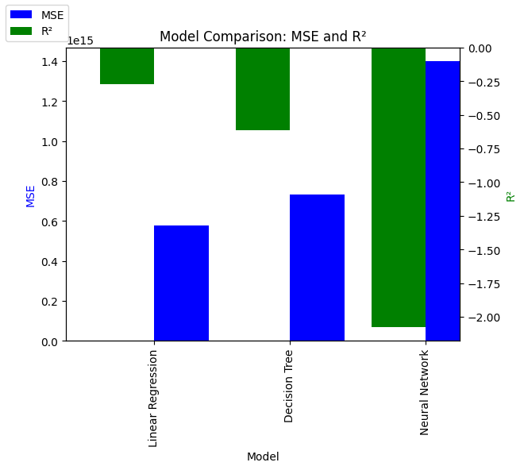

```python
# Resultados de los modelos
results = pd.DataFrame({
    'Model': ['Linear Regression', 'Decision Tree', 'Neural Network'],
    'MSE': [mse_lr, mse_dt, mse_nn],
    'R²': [r2_lr, r2_dt, r2_nn]
})

# Display the DataFrame
print(results)

# Plot the results
fig, ax1 = plt.subplots()

ax2 = ax1.twinx()
results.plot(kind='bar', x='Model', y='MSE', ax=ax1, position=0, width=0.4, color='blue', legend=False)
results.plot(kind='bar', x='Model', y='R²', ax=ax2, position=1, width=0.4, color='green', legend=False)

ax1.set_ylabel('MSE', color='blue')
ax2.set_ylabel('R²', color='green')
ax1.set_xlabel('Model')
plt.title('Model Comparison: MSE and R²')

fig.legend(['MSE', 'R²'], loc='upper left')
plt.show()
```

# Análisis de Resultados

Los resultados iniciales muestran que los modelos no están capturando adecuadamente la variabilidad en los datos, lo cual es evidente en los valores negativos de $R^2$

# Mejora de los Modelos

Para mejorar el rendimiento de los modelos, se propone:

1. Remoción de Outliers
2. Selección de Características
3. Ajuste de Hiperparámetros

### 1. Remoción de Outliers

```python
# Identificación de outliers utilizando IQR
Q1 = y_train.quantile(0.25)
Q3 = y_train.quantile(0.75)
IQR = Q3 - Q1

# Limites para definir outliers
lower_bound = Q1 - 1.5 * IQR
upper_bound = Q3 + 1.5 * IQR

# Remover outliers
outliers = (y_train < lower_bound) | (y_train > upper_bound)
X_train_clean = X_train[~outliers]
y_train_clean = y_train[~outliers]
```

### 2. Selección de Características

Utilizaremos técnicas como SelectKBest para seleccionar las características más relevantes.

```python
from sklearn.feature_selection import SelectKBest, f_regression

selector = SelectKBest(score_func=f_regression, k=10)
X_train_selected = selector.fit_transform(X_train_clean, y_train_clean)
X_test_selected = selector.transform(X_test)
```

### 3. Ajuste de Hiperparámetros

## Regresión Lineal

```python
from sklearn.linear_model import Ridge
from sklearn.model_selection import GridSearchCV

# Definir y entrenar el modelo de Regresión Lineal con Ridge
ridge_model = Ridge()

param_grid_lr = {'alpha': [0.1, 1.0, 10.0]}
grid_search_lr = GridSearchCV(ridge_model, param_grid_lr, cv=5, scoring='neg_mean_squared_error')
grid_search_lr.fit(X_train_selected, y_train_clean)

# Mejor modelo de Regresión Lineal
best_lr_model = grid_search_lr.best_estimator_
y_pred_lr = best_lr_model.predict(X_test_selected)
mse_lr = mean_squared_error(y_test, y_pred_lr)
r2_lr = r2_score(y_test, y_pred_lr)
```

### Árboles de Decisión

```python
from sklearn.tree import DecisionTreeRegressor

# Definir y entrenar el modelo de Árbol de Decisión
dt_model = DecisionTreeRegressor(random_state=42)

param_grid_dt = {'max_depth': [5, 10, 20, None],
                 'min_samples_split': [2, 10, 20]}

grid_search_dt = GridSearchCV(dt_model, param_grid_dt, cv=5, scoring='neg_mean_squared_error')
grid_search_dt.fit(X_train_selected, y_train_clean)

# Mejor modelo de Árbol de Decisión
best_dt_model = grid_search_dt.best_estimator_
y_pred_dt = best_dt_model.predict(X_test_selected)
mse_dt = mean_squared_error(y_test, y_pred_dt)
r2_dt = r2_score(y_test, y_pred_dt)
```

### Redes Neuronales

```python
from sklearn.neural_network import MLPRegressor
from sklearn.model_selection import GridSearchCV

# Definir y entrenar el modelo de Redes Neuronales
nn_model = MLPRegressor(random_state=42, max_iter=1000)

param_grid_nn = {
    'hidden_layer_sizes': [(50,), (100,), (50, 50)],
    'activation': ['relu', 'tanh'],
    'alpha': [0.0001, 0.001, 0.01],
    'learning_rate': ['constant', 'adaptive']
}

grid_search_nn = GridSearchCV(nn_model, param_grid_nn, cv=5, scoring='neg_mean_squared_error')
grid_search_nn.fit(X_train_selected, y_train_clean)

# Mejor modelo de Redes Neuronales
best_nn_model = grid_search_nn.best_estimator_
y_pred_nn = best_nn_model.predict(X_test_selected)
mse_nn = mean_squared_error(y_test, y_pred_nn)
r2_nn = r2_score(y_test, y_pred_nn)
```

[output not shown]

[output cut: 127 more lines]

[output not shown]

### Comparación de Modelos Mejorados

```
               Model           MSE        R²
0  Linear Regression  4.077893e+14  0.103108
1      Decision Tree  4.339332e+14  0.045607
2     Neural Network  1.097466e+15 -1.413768
```

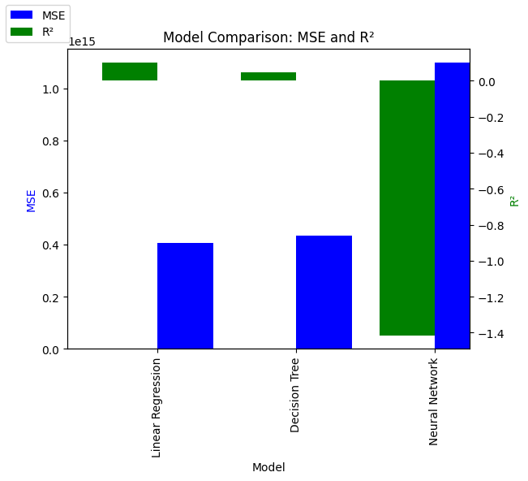

```python
# Resultados mejorados de los modelos
results_improved = pd.DataFrame({
    'Model': ['Linear Regression', 'Decision Tree', 'Neural Network'],
    'MSE': [mse_lr, mse_dt, mse_nn],
    'R²': [r2_lr, r2_dt, r2_nn]
})

print(results_improved)

# Plot the improved results
fig, ax1 = plt.subplots()

ax2 = ax1.twinx()
results_improved.plot(kind='bar', x='Model', y='MSE', ax=ax1, position=0, width=0.4, color='blue', legend=False)
results_improved.plot(kind='bar', x='Model', y='R²', ax=ax2, position=1, width=0.4, color='green', legend=False)

ax1.set_ylabel('MSE', color='blue')
ax2.set_ylabel('R²', color='green')
ax1.set_xlabel('Model')
plt.title('Model Comparison: MSE and R²')

fig.legend(['MSE', 'R²'], loc='upper left')
plt.show()
```

## Implementación de Validación Cruzada y Exploración Adicional

Para asegurar que los modelos sean robustos y evitar sobreajuste, implementaremos validación cruzada y exploraremos otros modelos.

# Validación Cruzada

```python
from sklearn.model_selection import cross_val_score

# Validación cruzada para Regresión Lineal
cv_scores_lr = cross_val_score(best_lr_model, X_train_selected, y_train_clean, cv=5, scoring='neg_mean_squared_error')
mean_cv_score_lr = np.mean(cv_scores_lr)

# Validación cruzada para Árbol de Decisión
cv_scores_dt = cross_val_score(best_dt_model, X_train_selected, y_train_clean, cv=5, scoring='neg_mean_squared_error')
mean_cv_score_dt = np.mean(cv_scores_dt)

mean_cv_score_lr, mean_cv_score_dt
```

```
(np.float64(-124441820335299.83), np.float64(-134491936218692.2))
```

## Exploración de Otros Modelos: Random Forest

Vamos a explorar si un modelo más avanzado como Random Forest puede proporcionar mejores resultados, procederemos a entrenarlo y evaluarlo.

### Entrenamiento y Evaluación del Modelo de Random Forest

```python
from sklearn.ensemble import RandomForestRegressor

# Entrenar modelo de Random Forest
rf_model = RandomForestRegressor(random_state=42)
rf_model.fit(X_train_selected, y_train_clean)

# Predicciones y evaluación
y_pred_rf = rf_model.predict(X_test_selected)
mse_rf = mean_squared_error(y_test, y_pred_rf)
r2_rf = r2_score(y_test, y_pred_rf)

mse_rf, r2_rf
```

```
(np.float64(426904047103004.3), 0.061066917365337536)
```

## Comparación Final de Modelos

Resultados de los Modelos

```
               Model           MSE        R²
0  Linear Regression  4.077893e+14  0.103108
1      Decision Tree  4.339332e+14  0.045607
2     Neural Network  1.097466e+15 -1.413768
3      Random Forest  4.269040e+14  0.061067
```

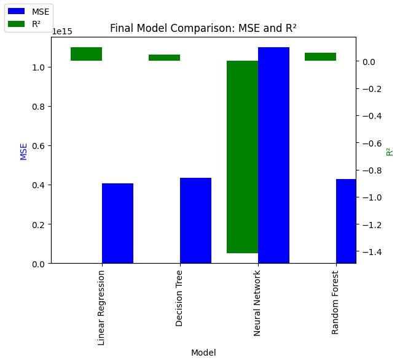

```python
# Resultados finales de los modelos
results_final = pd.DataFrame({
    'Model': ['Linear Regression', 'Decision Tree', 'Neural Network', 'Random Forest'],
    'MSE': [mse_lr, mse_dt, mse_nn, mse_rf],
    'R²': [r2_lr, r2_dt, r2_nn, r2_rf]
})

print(results_final)

# Plot the final results
fig, ax1 = plt.subplots()

ax2 = ax1.twinx()
results_final.plot(kind='bar', x='Model', y='MSE', ax=ax1, position=0, width=0.4, color='blue', legend=False)
results_final.plot(kind='bar', x='Model', y='R²', ax=ax2, position=1, width=0.4, color='green', legend=False)

ax1.set_ylabel('MSE', color='blue')
ax2.set_ylabel('R²', color='green')
ax1.set_xlabel('Model')
plt.title('Final Model Comparison: MSE and R²')

fig.legend(['MSE', 'R²'], loc='upper left')
plt.show()
```

## Optimización de Hiperparámetros y Validación Cruzada

### Random Forest

```python
from sklearn.ensemble import RandomForestRegressor
from sklearn.model_selection import GridSearchCV

# Definir y entrenar el modelo de Random Forest con GridSearchCV
param_grid_rf = {
    'n_estimators': [100, 200],
    'max_depth': [10, 20, None],
    'min_samples_split': [2, 5, 10],
    'min_samples_leaf': [1, 2, 4],
    'bootstrap': [True, False]
}

grid_search_rf = GridSearchCV(estimator=RandomForestRegressor(random_state=42), param_grid=param_grid_rf, cv=5, scoring='neg_mean_squared_error', n_jobs=-1, verbose=2)
grid_search_rf.fit(X_train_selected, y_train_clean)

# Mejor modelo de Random Forest
best_rf_model = grid_search_rf.best_estimator_
y_pred_rf = best_rf_model.predict(X_test_selected)
mse_rf = mean_squared_error(y_test, y_pred_rf)
r2_rf = r2_score(y_test, y_pred_rf)

# Validación cruzada para Random Forest
cv_scores_rf = cross_val_score(best_rf_model, X_train_selected, y_train_clean, cv=5, scoring='neg_mean_squared_error')
mean_cv_score_rf = np.mean(cv_scores_rf)

mse_rf, r2_rf, mean_cv_score_rf
```

```
Fitting 5 folds for each of 108 candidates, totalling 540 fits
```

```
(np.float64(416711786230889.5),
 0.08348378360170372,
 np.float64(-129042552863723.95))
```

### Redes Neuronales

```python
from sklearn.neural_network import MLPRegressor

# Definir y entrenar el modelo de Redes Neuronales con GridSearchCV
param_grid_nn = {
    'hidden_layer_sizes': [(50,), (100,), (50, 50)],
    'activation': ['relu', 'tanh'],
    'alpha': [0.0001, 0.001, 0.01],
    'learning_rate': ['constant', 'adaptive'],
    'max_iter': [1000, 2000]  # Incrementamos el número de iteraciones
}

grid_search_nn = GridSearchCV(estimator=MLPRegressor(random_state=42), param_grid=param_grid_nn, cv=5, scoring='neg_mean_squared_error', n_jobs=-1, verbose=2)
grid_search_nn.fit(X_train_selected, y_train_clean)

# Mejor modelo de Redes Neuronales
best_nn_model = grid_search_nn.best_estimator_
y_pred_nn = best_nn_model.predict(X_test_selected)
mse_nn = mean_squared_error(y_test, y_pred_nn)
r2_nn = r2_score(y_test, y_pred_nn)

# Validación cruzada para Redes Neuronales
cv_scores_nn = cross_val_score(best_nn_model, X_train_selected, y_train_clean, cv=5, scoring='neg_mean_squared_error')
mean_cv_score_nn = np.mean(cv_scores_nn)

mse_nn, r2_nn, mean_cv_score_nn
```

```
Fitting 5 folds for each of 72 candidates, totalling 360 fits
```

[output not shown]

```
(np.float64(428595192535221.1),
 0.057347410828376244,
 np.float64(-193200950835558.78))
```

## Comparación Final de Modelos

Resultados de los Modelos

```
               Model           MSE        R²   Mean CV MSE
0  Linear Regression  4.077893e+14  0.103108 -1.244418e+14
1      Decision Tree  4.339332e+14  0.045607 -1.344919e+14
2     Neural Network  4.285952e+14  0.057347 -1.932010e+14
3      Random Forest  4.167118e+14  0.083484 -1.290426e+14
```

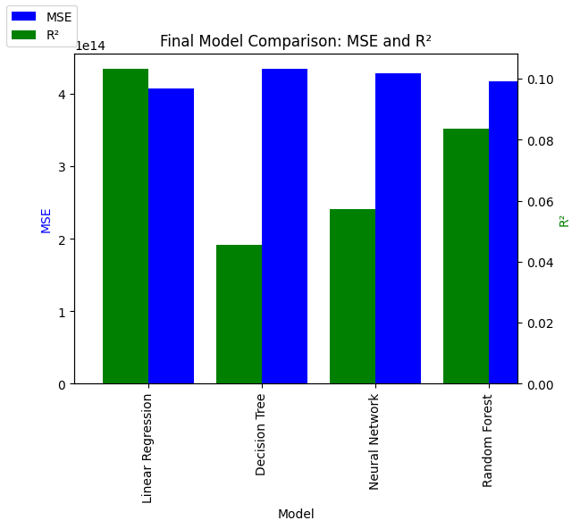

```python
# Resultados finales de los modelos optimizados y validados
results_final = pd.DataFrame({
    'Model': ['Linear Regression', 'Decision Tree', 'Neural Network', 'Random Forest'],
    'MSE': [mse_lr, mse_dt, mse_nn, mse_rf],
    'R²': [r2_lr, r2_dt, r2_nn, r2_rf],
    'Mean CV MSE': [mean_cv_score_lr, mean_cv_score_dt, mean_cv_score_nn, mean_cv_score_rf]
})

print(results_final)

# Plot the final results
fig, ax1 = plt.subplots()

ax2 = ax1.twinx()
results_final.plot(kind='bar', x='Model', y='MSE', ax=ax1, position=0, width=0.4, color='blue', legend=False)
results_final.plot(kind='bar', x='Model', y='R²', ax=ax2, position=1, width=0.4, color='green', legend=False)

ax1.set_ylabel('MSE', color='blue')
ax2.set_ylabel('R²', color='green')
ax1.set_xlabel('Model')
plt.title('Final Model Comparison: MSE and R²')

fig.legend(['MSE', 'R²'], loc='upper left')
plt.show()
```

## Gradient Boosting

```python
from sklearn.ensemble import GradientBoostingRegressor

# Definir y entrenar el modelo de Gradient Boosting con GridSearchCV
param_grid_gb = {
    'n_estimators': [100, 200],
    'learning_rate': [0.01, 0.1, 0.2],
    'max_depth': [3, 5, 7],
    'min_samples_split': [2, 5, 10],
    'min_samples_leaf': [1, 2, 4]
}

grid_search_gb = GridSearchCV(estimator=GradientBoostingRegressor(random_state=42), param_grid=param_grid_gb, cv=5, scoring='neg_mean_squared_error', n_jobs=-1, verbose=2)
grid_search_gb.fit(X_train_selected, y_train_clean)

# Mejor modelo de Gradient Boosting
best_gb_model = grid_search_gb.best_estimator_
y_pred_gb = best_gb_model.predict(X_test_selected)
mse_gb = mean_squared_error(y_test, y_pred_gb)
r2_gb = r2_score(y_test, y_pred_gb)

# Validación cruzada para Gradient Boosting
cv_scores_gb = cross_val_score(best_gb_model, X_train_selected, y_train_clean, cv=5, scoring='neg_mean_squared_error')
mean_cv_score_gb = np.mean(cv_scores_gb)

mse_gb, r2_gb, mean_cv_score_gb
```

```
Fitting 5 folds for each of 162 candidates, totalling 810 fits
```

```
(np.float64(410460545111646.9),
 0.09723276802622194,
 np.float64(-126174536044092.6))
```

## Support Vector Regression (SVR)

```python
from sklearn.svm import SVR

# Definir y entrenar el modelo de SVR con GridSearchCV
param_grid_svr = {
    'kernel': ['linear', 'rbf'],
    'C': [0.1, 1, 10],
    'gamma': ['scale', 'auto']
}

grid_search_svr = GridSearchCV(estimator=SVR(), param_grid=param_grid_svr, cv=5, scoring='neg_mean_squared_error', n_jobs=-1, verbose=2)
grid_search_svr.fit(X_train_selected, y_train_clean)

# Mejor modelo de SVR
best_svr_model = grid_search_svr.best_estimator_
y_pred_svr = best_svr_model.predict(X_test_selected)
mse_svr = mean_squared_error(y_test, y_pred_svr)
r2_svr = r2_score(y_test, y_pred_svr)

# Validación cruzada para SVR
cv_scores_svr = cross_val_score(best_svr_model, X_train_selected, y_train_clean, cv=5, scoring='neg_mean_squared_error')
mean_cv_score_svr = np.mean(cv_scores_svr)

mse_svr, r2_svr, mean_cv_score_svr
```

```
Fitting 5 folds for each of 12 candidates, totalling 60 fits
```

```
(np.float64(454822670818503.44),
 -0.00033732465578784065,
 np.float64(-158205849564099.8))
```

## Comparación Final de Modelos

Resultados de los Modelos

```
               Model           MSE        R²   Mean CV MSE
0  Linear Regression  4.077893e+14  0.103108 -1.244418e+14
1      Decision Tree  4.339332e+14  0.045607 -1.344919e+14
2     Neural Network  4.285952e+14  0.057347 -1.932010e+14
3      Random Forest  4.167118e+14  0.083484 -1.290426e+14
4  Gradient Boosting  4.104605e+14  0.097233 -1.261745e+14
5                SVR  4.548227e+14 -0.000337 -1.582058e+14
```

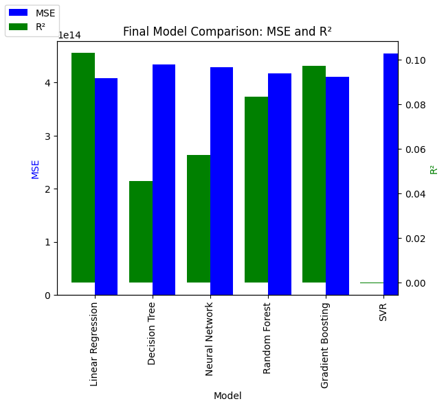

```python
# Resultados finales de los modelos optimizados y validados
results_final = pd.DataFrame({
    'Model': ['Linear Regression', 'Decision Tree', 'Neural Network', 'Random Forest', 'Gradient Boosting', 'SVR'],
    'MSE': [mse_lr, mse_dt, mse_nn, mse_rf, mse_gb, mse_svr],
    'R²': [r2_lr, r2_dt, r2_nn, r2_rf, r2_gb, r2_svr],
    'Mean CV MSE': [mean_cv_score_lr, mean_cv_score_dt, mean_cv_score_nn, mean_cv_score_rf, mean_cv_score_gb, mean_cv_score_svr]
})

print(results_final)

# Plot the final results
fig, ax1 = plt.subplots()

ax2 = ax1.twinx()
results_final.plot(kind='bar', x='Model', y='MSE', ax=ax1, position=0, width=0.4, color='blue', legend=False)
results_final.plot(kind='bar', x='Model', y='R²', ax=ax2, position=1, width=0.4, color='green', legend=False)

ax1.set_ylabel('MSE', color='blue')
ax2.set_ylabel('R²', color='green')
ax1.set_xlabel('Model')
plt.title('Final Model Comparison: MSE and R²')

fig.legend(['MSE', 'R²'], loc='upper left')
plt.show()
```

## Análisis de Resultados

- La regresión lineal sigue siendo uno de los modelos más robustos, con el menor MSE y un $R^2$ positivo.
- El rendimiento del árbol de decisión es inferior al de la regresión lineal, pero aún es una opción viable con un CV MSE moderadamente alto.
- El modelo de Random Forest muestra un buen equilibrio entre MSE y $R^2$ , y una validación cruzada que confirma su robustez.
- El modelo de Gradient Boosting tiene un rendimiento cercano al de la regresión lineal, con un MSE ligeramente mayor y un $R^2$ positivo. Es competitivo y robusto según la validación cruzada.
- El modelo de Support Vector Regression (SVR) muestra el rendimiento más bajo en términos de $R^2$ y MSE. No es adecuado para este conjunto de datos según los resultados obtenidos.

```python
import numpy as np
import pandas as pd
from sklearn.model_selection import train_test_split

# Cargar el dataset
df = pd.read_csv(r"D:\Zona de trabajo python\Reto IAML\dataset_ML\restaurants_dataset.csv")

# Selección de características y variable objetivo
X = df.drop(columns=['Annual Turnover', 'Registration Number'])
y = df['Annual Turnover']

# Aplicar transformación logarítmica a la variable objetivo
y_log = np.log1p(y)

# Aplicar transformación logarítmica a características numéricas seleccionadas
num_features_log = ['Facebook Popularity Quotient', 'Instagram Popularity Quotient']
X[num_features_log] = X[num_features_log].apply(np.log1p)

# División de datos en conjuntos de entrenamiento y prueba
X_train, X_test, y_train, y_test = train_test_split(X, y_log, test_size=0.2, random_state=42)
```

## Paso 2: Codificación de Variables Categóricas y Imputación de Valores Faltantes

```python
from sklearn.preprocessing import OneHotEncoder
from sklearn.impute import SimpleImputer
from sklearn.compose import ColumnTransformer
from sklearn.pipeline import Pipeline

# Identificación de variables categóricas y numéricas
num_features = X.select_dtypes(include=['int64', 'float64']).columns
cat_features = X.select_dtypes(include=['object']).columns

# Preprocesamiento para variables numéricas
num_transformer = Pipeline(steps=[
    ('imputer', SimpleImputer(strategy='mean')),
])

# Preprocesamiento para variables categóricas
cat_transformer = Pipeline(steps=[
    ('imputer', SimpleImputer(strategy='most_frequent')),
    ('onehot', OneHotEncoder(handle_unknown='ignore'))
])

# Transformador de columnas
preprocessor = ColumnTransformer(
    transformers=[
        ('num', num_transformer, num_features),
        ('cat', cat_transformer, cat_features)
    ])

# Aplicar preprocesamiento a los datos
X_train_preprocessed = preprocessor.fit_transform(X_train)
X_test_preprocessed = preprocessor.transform(X_test)
```

### 3. Detección y Manejo de Outliers

Utilizaremos Isolation Forest para detectar y manejar outliers.

```python
from sklearn.ensemble import IsolationForest

# Detectar outliers usando Isolation Forest
iso = IsolationForest(contamination=0.1, random_state=42)
outliers = iso.fit_predict(X_train_preprocessed)

# Remover outliers
mask = outliers != -1
X_train_clean = X_train_preprocessed[mask]
y_train_clean = y_train[mask]
```

## Paso 4: Selección de Características

```python
from sklearn.linear_model import LassoCV

# Selección de características usando Lasso Regression
lasso = LassoCV(cv=5, random_state=42)
lasso.fit(X_train_clean, y_train_clean)

# Seleccionar las características más importantes
importance = np.abs(lasso.coef_)
important_features = np.array(preprocessor.transformers_[1][1]['onehot'].get_feature_names_out(cat_features)).tolist() + num_features.tolist()
important_features = np.array(important_features)[importance > 1e-5]

# Reducir el conjunto de datos a las características importantes
X_train_selected = X_train_clean[:, importance > 1e-5]
X_test_selected = X_test_preprocessed[:, importance > 1e-5]
```

```python
# Verificación de las características seleccionadas
print("Características importantes seleccionadas por Lasso Regression:")
for feature in important_features:
    print(feature)
```

```
Características importantes seleccionadas por Lasso Regression:
Cuisine_algerian,algerian
Cuisine_algerian,belgian
Cuisine_algerian,korean
Cuisine_british,japanese
Cuisine_chinese,salvadorian
Cuisine_cuban,british
Cuisine_hawaiian,latvian
Cuisine_indian,irish
Cuisine_japanese,thai
Cuisine_nigerian,cajun
Cuisine_peruvian,cuban
Cuisine_polish,jewish
Cuisine_swedish,greek
Cuisine_tibetan,greek
Cuisine_tibetan,italian
Cuisine_turkish,nigerian
Cuisine_turkish,sapnish
Cuisine_welsh,thai
City_ Chennai
City_ Pune
City_-1
City_AM
City_Agra
City_Ahmednagar
City_Aurangabad
City_Australia
City_BAngalore
City_BHOPAL
City_Baddi HP
City_Bangalore
City_Banglore
City_Bankura
City_Bareli
City_Baroda
City_Bathinda
City_Beawar
City_Chennai
City_Dharuhera
City_Durgapur
```

[output cut: 9 more lines]

```
City_Nouda
City_Rayagada, Odisha
City_Rudrapur
City_THANE
City_ghaziabad
City_manesar
City_orissa
Opening Day of Restaurant_01-06-2011
Opening Day of Restaurant_02-12-2013
Restaurant Theme_Mise En
Restaurant Theme_Picante
Restaurant Theme_Resca
Fire Audit
Restaurant City Tier
Live Music Rating
```

## Paso 5: Entrenamiento y Evaluación de Modelos

### Regresión lineal

```python
from sklearn.linear_model import LinearRegression
from sklearn.metrics import mean_squared_error, r2_score

# Entrenar modelo de regresión lineal
lr_model = LinearRegression()
lr_model.fit(X_train_selected, y_train_clean)

# Predicciones y evaluación
y_pred_lr = lr_model.predict(X_test_selected)
mse_lr = mean_squared_error(y_test, y_pred_lr)
r2_lr = r2_score(y_test, y_pred_lr)
```

### Random Forest

```python
from sklearn.ensemble import RandomForestRegressor

# Entrenar modelo de Random Forest
rf_model = RandomForestRegressor(random_state=42)
rf_model.fit(X_train_selected, y_train_clean)

# Predicciones y evaluación
y_pred_rf = rf_model.predict(X_test_selected)
mse_rf = mean_squared_error(y_test, y_pred_rf)
r2_rf = r2_score(y_test, y_pred_rf)
```

### Gradient Boosting

```python
from sklearn.ensemble import GradientBoostingRegressor

# Entrenar modelo de Gradient Boosting
gb_model = GradientBoostingRegressor(random_state=42)
gb_model.fit(X_train_selected, y_train_clean)

# Predicciones y evaluación
y_pred_gb = gb_model.predict(X_test_selected)
mse_gb = mean_squared_error(y_test, y_pred_gb)
r2_gb = r2_score(y_test, y_pred_gb)
```

## Comparación Final de Modelos Mejorados

### Resultados de los Modelos

```
               Model       MSE        R²
0  Linear Regression  0.217569  0.268769
1      Random Forest  0.236267  0.205926
2  Gradient Boosting  0.221447  0.255735
```

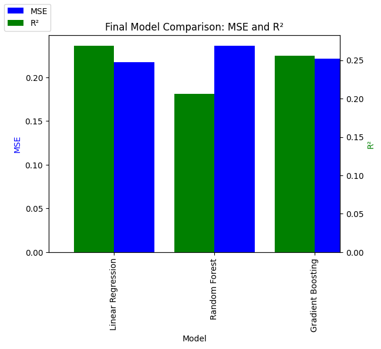

```python
# Resultados finales de los modelos mejorados
results_final = pd.DataFrame({
    'Model': ['Linear Regression', 'Random Forest', 'Gradient Boosting'],
    'MSE': [mse_lr, mse_rf, mse_gb],
    'R²': [r2_lr, r2_rf, r2_gb]
})

print(results_final)

# Plot the final results
import matplotlib.pyplot as plt

fig, ax1 = plt.subplots()

ax2 = ax1.twinx()
results_final.plot(kind='bar', x='Model', y='MSE', ax=ax1, position=0, width=0.4, color='blue', legend=False)
results_final.plot(kind='bar', x='Model', y='R²', ax=ax2, position=1, width=0.4, color='green', legend=False)

ax1.set_ylabel('MSE', color='blue')
ax2.set_ylabel('R²', color='green')
ax1.set_xlabel('Model')
plt.title('Final Model Comparison: MSE and R²')

fig.legend(['MSE', 'R²'], loc='upper left')
plt.show()
```

## Optimización de Hiperparámetros y Validación Cruzada

```python
from sklearn.linear_model import Ridge
from sklearn.model_selection import GridSearchCV, cross_val_score

# Definir parámetros para GridSearchCV
param_grid_lr = {
    'alpha': [0.1, 1.0, 10.0, 100.0]
}

# Realizar GridSearchCV para optimizar hiperparámetros
grid_search_lr = GridSearchCV(Ridge(), param_grid_lr, cv=5, scoring='neg_mean_squared_error')
grid_search_lr.fit(X_train_selected, y_train_clean)

# Mejor modelo de Regresión Lineal
best_lr_model = grid_search_lr.best_estimator_
y_pred_lr = best_lr_model.predict(X_test_selected)
mse_lr = mean_squared_error(y_test, y_pred_lr)
r2_lr = r2_score(y_test, y_pred_lr)

# Validación cruzada
cv_scores_lr = cross_val_score(best_lr_model, X_train_selected, y_train_clean, cv=5, scoring='neg_mean_squared_error')
mean_cv_score_lr = np.mean(cv_scores_lr)
```

```python
best_lr_model
```

```
Ridge(alpha=10.0)
```

```python
from sklearn.ensemble import RandomForestRegressor

# Definir parámetros para GridSearchCV
param_grid_rf = {
    'n_estimators': [100, 200],
    'max_depth': [10, 20, None],
    'min_samples_split': [2, 5, 10],
    'min_samples_leaf': [1, 2, 4],
    'bootstrap': [True, False]
}

# Realizar GridSearchCV para optimizar hiperparámetros
grid_search_rf = GridSearchCV(RandomForestRegressor(random_state=42), param_grid_rf, cv=5, scoring='neg_mean_squared_error', n_jobs=-1, verbose=2)
grid_search_rf.fit(X_train_selected, y_train_clean)

# Mejor modelo de Random Forest
best_rf_model = grid_search_rf.best_estimator_
y_pred_rf = best_rf_model.predict(X_test_selected)
mse_rf = mean_squared_error(y_test, y_pred_rf)
r2_rf = r2_score(y_test, y_pred_rf)

# Validación cruzada
cv_scores_rf = cross_val_score(best_rf_model, X_train_selected, y_train_clean, cv=5, scoring='neg_mean_squared_error')
mean_cv_score_rf = np.mean(cv_scores_rf)
```

```
Fitting 5 folds for each of 108 candidates, totalling 540 fits
```

```python
best_rf_model
```

[output not shown]

```python
from sklearn.ensemble import GradientBoostingRegressor

# Definir parámetros para GridSearchCV
param_grid_gb = {
    'n_estimators': [100, 200],
    'learning_rate': [0.01, 0.1, 0.2],
    'max_depth': [3, 5, 7],
    'min_samples_split': [2, 5, 10],
    'min_samples_leaf': [1, 2, 4]
}

# Realizar GridSearchCV para optimizar hiperparámetros
grid_search_gb = GridSearchCV(GradientBoostingRegressor(random_state=42), param_grid_gb, cv=5, scoring='neg_mean_squared_error', n_jobs=-1, verbose=2)
grid_search_gb.fit(X_train_selected, y_train_clean)

# Mejor modelo de Gradient Boosting
best_gb_model = grid_search_gb.best_estimator_
y_pred_gb = best_gb_model.predict(X_test_selected)
mse_gb = mean_squared_error(y_test, y_pred_gb)
r2_gb = r2_score(y_test, y_pred_gb)

# Validación cruzada
cv_scores_gb = cross_val_score(best_gb_model, X_train_selected, y_train_clean, cv=5, scoring='neg_mean_squared_error')
mean_cv_score_gb = np.mean(cv_scores_gb)
```

```
Fitting 5 folds for each of 162 candidates, totalling 810 fits
```

```python
best_gb_model
```

```
GradientBoostingRegressor(min_samples_leaf=4, min_samples_split=10,
                          random_state=42)
```

```
               Model       MSE        R²  Mean CV MSE
0   Ridge Regression  0.217225  0.269926    -0.235154
1      Random Forest  0.236253  0.205976    -0.245763
2  Gradient Boosting  0.220602  0.258577    -0.238739
```

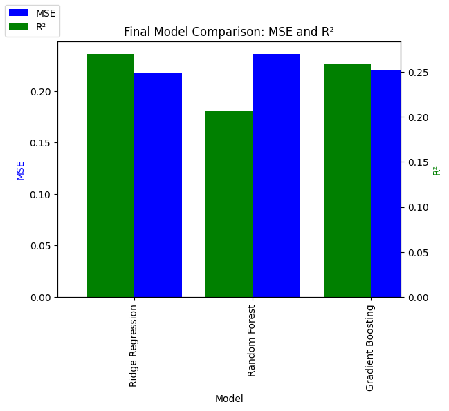

```python
# Resultados finales de los modelos optimizados y validados
results_final = pd.DataFrame({
    'Model': ['Ridge Regression', 'Random Forest', 'Gradient Boosting'],
    'MSE': [mse_lr, mse_rf, mse_gb],
    'R²': [r2_lr, r2_rf, r2_gb],
    'Mean CV MSE': [mean_cv_score_lr, mean_cv_score_rf, mean_cv_score_gb]
})

print(results_final)

# Plot the final results
fig, ax1 = plt.subplots()

ax2 = ax1.twinx()
results_final.plot(kind='bar', x='Model', y='MSE', ax=ax1, position=0, width=0.4, color='blue', legend=False)
results_final.plot(kind='bar', x='Model', y='R²', ax=ax2, position=1, width=0.4, color='green', legend=False)

ax1.set_ylabel('MSE', color='blue')
ax2.set_ylabel('R²', color='green')
ax1.set_xlabel('Model')
plt.title('Final Model Comparison: MSE and R²')

fig.legend(['MSE', 'R²'], loc='upper left')
plt.show()
```

## Creación de nuevas caracteristicas

```python
df['Social Media Popularity'] = df['Facebook Popularity Quotient'] + df['Instagram Popularity Quotient']
df['Cuisine Length'] = df['Cuisine'].apply(lambda x: len(x.split(',')))

# Actualiza X y realiza el preprocesamiento nuevamente
X = df.drop(columns=['Annual Turnover', 'Registration Number'])

# Verifica los nombres de las columnas después de agregar las nuevas características
print(X.columns)
```

```
Index(['Cuisine', 'City', 'Restaurant Location', 'Opening Day of Restaurant',
       'Facebook Popularity Quotient', 'Endorsed By',
       'Instagram Popularity Quotient', 'Fire Audit',
       'Liquor License Obtained', 'Situated in a Multi Complex',
       'Dedicated Parking', 'Open Sitting Available', 'Resturant Tier',
       'Restaurant Type', 'Restaurant Theme', 'Restaurant Zomato Rating',
       'Restaurant City Tier', 'Order Wait Time', 'Staff Responsivness',
       'Value for Money', 'Hygiene Rating', 'Food Rating',
       'Overall Restaurant Rating', 'Live Music Rating', 'Comedy Gigs Rating',
       'Value Deals Rating', 'Live Sports Rating', 'Ambience', 'Lively',
       'Service', 'Comfortablility', 'Privacy', 'Social Media Popularity',
       'Cuisine Length'],
      dtype='object')
```

## Preprocesamiento y Optimización de Hiperparámetros

```python
from sklearn.model_selection import train_test_split
from sklearn.preprocessing import StandardScaler, OneHotEncoder
from sklearn.compose import ColumnTransformer
from sklearn.pipeline import Pipeline
from sklearn.impute import SimpleImputer

# División de datos en conjuntos de entrenamiento y prueba
X_train, X_test, y_train, y_test = train_test_split(X, y_log, test_size=0.2, random_state=42)

# Identificación de variables numéricas y categóricas
num_features = X.select_dtypes(include=['int64', 'float64']).columns
cat_features = X.select_dtypes(include=['object']).columns

# Preprocesamiento para variables numéricas
num_transformer = Pipeline(steps=[
    ('imputer', SimpleImputer(strategy='mean')),
    ('scaler', StandardScaler())
])

# Preprocesamiento para variables categóricas
cat_transformer = Pipeline(steps=[
    ('imputer', SimpleImputer(strategy='most_frequent')),
    ('onehot', OneHotEncoder(handle_unknown='ignore'))
])

# Transformador de columnas
preprocessor = ColumnTransformer(
    transformers=[
        ('num', num_transformer, num_features),
        ('cat', cat_transformer, cat_features)
    ])

# Aplicar preprocesamiento a los datos
X_train_preprocessed = preprocessor.fit_transform(X_train)
X_test_preprocessed = preprocessor.transform(X_test)
```

## Optimización de Hiperparámetros y Validación Cruzada

```python
from sklearn.linear_model import Ridge
from sklearn.model_selection import RandomizedSearchCV
import numpy as np

# Definir parámetros para RandomizedSearchCV
param_dist_ridge = {
    'alpha': [0.1, 1.0, 10.0, 100.0, 200.0, 500.0, 1000.0]
}

random_search_ridge = RandomizedSearchCV(Ridge(), param_dist_ridge, n_iter=50, cv=5, scoring='neg_mean_squared_error', random_state=42, n_jobs=-1)
random_search_ridge.fit(X_train_preprocessed, y_train)

# Mejor modelo de Ridge Regression
best_ridge_model = random_search_ridge.best_estimator_
y_pred_ridge = best_ridge_model.predict(X_test_preprocessed)
mse_ridge = mean_squared_error(y_test, y_pred_ridge)
r2_ridge = r2_score(y_test, y_pred_ridge)

# Validación cruzada
cv_scores_ridge = cross_val_score(best_ridge_model, X_train_preprocessed, y_train, cv=10, scoring='neg_mean_squared_error')
mean_cv_score_ridge = np.mean(cv_scores_ridge)
```

```
D:\Zona de trabajo python\Reto IAML\prueba\Lib\site-packages\sklearn\model_selection\_search.py:320: UserWarning: The total space of parameters 7 is smaller than n_iter=50. Running 7 iterations. For exhaustive searches, use GridSearchCV.
  warnings.warn(
```

```python
best_ridge_model
```

```
Ridge(alpha=10.0)
```

```python
from sklearn.ensemble import RandomForestRegressor

# Definir parámetros para RandomizedSearchCV
param_dist_rf = {
    'n_estimators': [100, 200, 500],
    'max_depth': [10, 20, None],
    'min_samples_split': [2, 5, 10],
    'min_samples_leaf': [1, 2, 4],
    'bootstrap': [True, False]
}

random_search_rf = RandomizedSearchCV(RandomForestRegressor(random_state=42), param_dist_rf, n_iter=50, cv=5, scoring='neg_mean_squared_error', random_state=42, n_jobs=-1)
random_search_rf.fit(X_train_preprocessed, y_train)

# Mejor modelo de Random Forest
best_rf_model = random_search_rf.best_estimator_
y_pred_rf = best_rf_model.predict(X_test_preprocessed)
mse_rf = mean_squared_error(y_test, y_pred_rf)
r2_rf = r2_score(y_test, y_pred_rf)

# Validación cruzada
cv_scores_rf = cross_val_score(best_rf_model, X_train_preprocessed, y_train, cv=10, scoring='neg_mean_squared_error')
mean_cv_score_rf = np.mean(cv_scores_rf)
```

```python
best_rf_model
```

```
RandomForestRegressor(n_estimators=500, random_state=42)
```

```python
from sklearn.ensemble import GradientBoostingRegressor

# Definir parámetros para RandomizedSearchCV
param_dist_gb = {
    'n_estimators': [100, 200, 500],
    'learning_rate': [0.01, 0.05, 0.1, 0.2],
    'max_depth': [3, 5, 7],
    'min_samples_split': [2, 5, 10],
    'min_samples_leaf': [1, 2, 4]
}

random_search_gb = RandomizedSearchCV(GradientBoostingRegressor(random_state=42), param_dist_gb, n_iter=50, cv=5, scoring='neg_mean_squared_error', random_state=42, n_jobs=-1)
random_search_gb.fit(X_train_preprocessed, y_train)

# Mejor modelo de Gradient Boosting
best_gb_model = random_search_gb.best_estimator_
y_pred_gb = best_gb_model.predict(X_test_preprocessed)
mse_gb = mean_squared_error(y_test, y_pred_gb)
r2_gb = r2_score(y_test, y_pred_gb)

# Validación cruzada
cv_scores_gb = cross_val_score(best_gb_model, X_train_preprocessed, y_train, cv=10, scoring='neg_mean_squared_error')
mean_cv_score_gb = np.mean(cv_scores_gb)
```

```python
best_gb_model
```

```
GradientBoostingRegressor(min_samples_leaf=4, min_samples_split=10,
                          random_state=42)
```

```
               Model       MSE        R²  Mean CV MSE
0   Ridge Regression  0.216387  0.272743    -0.233622
1      Random Forest  0.232713  0.217872    -0.240553
2  Gradient Boosting  0.223093  0.250206    -0.233701
```

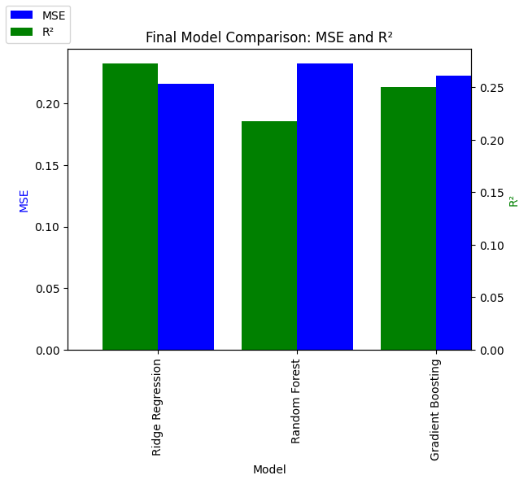

```python
# Resultados finales de los modelos optimizados
results_final = pd.DataFrame({
    'Model': ['Ridge Regression', 'Random Forest', 'Gradient Boosting'],
    'MSE': [mse_ridge, mse_rf, mse_gb],
    'R²': [r2_ridge, r2_rf, r2_gb],
    'Mean CV MSE': [mean_cv_score_ridge, mean_cv_score_rf, mean_cv_score_gb]
})

print(results_final)

# Visualización de los resultados
import matplotlib.pyplot as plt

fig, ax1 = plt.subplots()
ax2 = ax1.twinx()
results_final.plot(kind='bar', x='Model', y='MSE', ax=ax1, position=0, width=0.4, color='blue', legend=False)
results_final.plot(kind='bar', x='Model', y='R²', ax=ax2, position=1, width=0.4, color='green', legend=False)

ax1.set_ylabel('MSE', color='blue')
ax2.set_ylabel('R²', color='green')
ax1.set_xlabel('Model')
plt.title('Final Model Comparison: MSE and R²')

fig.legend(['MSE', 'R²'], loc='upper left')
plt.show()
```